# Week 6 TA sync session

### 6.0 Agenda

In this session, we will look at:

- Understand integration as an anti-derivative
- Implement integration by substitution
- Implement integration by parts
- Divide a function into partial factors
- Implement improper integrals

### 6.1 Integtation - as an anti derivative

##### Overview

Integration is essentially the reverse of differentiation, meaning it helps reconstruct the original function from its rate of change. This is why integration is often referred to as finding the **anti-derivative.**

```python
import numpy  as np
import mpmath as mp
import sympy  as sp
import warnings
warnings.filterwarnings("ignore")
```

```python
#Let us use sympy integrate method first
#Ref: https://docs.sympy.org/latest/modules/integrals/integrals.html

x = sp.symbols('x')
f = sp.sin(x)*sp.exp(-x) #sp.exp is e to the power -x

print('Original function f:')
display(f)

# Use sympy.integrate() method
fi = sp.integrate(f, x)
print('\n\nIntegration of f:fi - ')
display(fi)

f1 = sp.simplify(sp.diff(fi,x))
print('\n\nDerivative of fi. Should be same as original function f:')
display(f, f1)
```

```
Original function f:
```

$\displaystyle e^{- x} \sin{\left(x \right)}$

```
Integration of f:fi -
```

$\displaystyle - \frac{e^{- x} \sin{\left(x \right)}}{2} - \frac{e^{- x} \cos{\left(x \right)}}{2}$

```
Derivative of fi. Should be same as original function f:
```

$\displaystyle e^{- x} \sin{\left(x \right)}$

$\displaystyle e^{- x} \sin{\left(x \right)}$

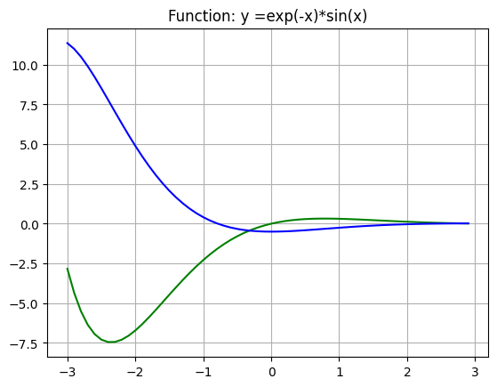

```python
# Now, we will plot the original function and it's anti-derivative function
x1  = np.arange(-3,3,0.1)
mark = []

import matplotlib.pyplot as plt

plt.plot(x1, sp.lambdify(x,f)(x1),'-gD',markevery=mark, label=f)
plt.plot(x1, sp.lambdify(x,fi)(x1),'-bD',markevery=mark,label=fi)
plt.grid(which='major')
plt.title('Function: y ={}'.format(f));
plt.show()
```

```python
# we can also directly find value of an integration of a function between two limits
s = sp.integrate(f, (x,0,sp.oo))
print(s)
```

```
1/2
```

```python
#Mpmath provides symbolic integration capabilities using the mp.quad and mp.quadosc(where x can be oo) functions.
#Ref: https://www.omz-software.com/pythonista/sympy/modules/mpmath/calculus/integration.html

#You can integrate functions symbolically and evaluate definite integrals:
g = lambda x: sp.sin(x)*sp.exp(-x)

r = mp.quad(g, [0, mp.inf])
print (r)
```

```
0.5
```

```python
#We also have quad function in scify library package
#Ref: https://www.geeksforgeeks.org/scipy-integration/

from scipy.integrate import quad
I, err = quad(g, 0, sp.oo)
print(I)
print(err)
```

```
0.5000000000000002
1.4875911973447058e-08
```

### 6.2 Integration by substitution

##### Overview

Integration by substitution involves replacing a complex expression in the integral with a simpler variable, making integration easier.

```python
#How to substiture function of x and its derivative to carry out integration by substitution:

x, y, a = sp.symbols('x y a')

def int_by_subs(f,a):
    '''
    This function supports integration by a substitution method

    Inputs: f: The original function you want to integrate
            a: part of original function we want to substitute

    Returns: Integration of the original function, performed by substitution method
    '''
    display('Original function f:',f)
    display('part of the function to be substituted a:',a)
    display('We will substiture y (and its dy) in place of expression:',a)
    fn = f.subs(a,y).subs(sp.diff(a),1)
    display('After substitution, the function is expresses in terms of y as:',fn)
    fni = sp.integrate(fn)
    display('Integration of this function:',fni)
    fi =  fni.subs(y,a)
    display('finally replacing y with a, we get back integration of original function:',fi)
    f2 = fi.diff(x)
    display('Validate by taking the derivative of this integration:',f2)
    return fi


print('Let us find integration of a function f:')
f = ((2*x**3+1)**4)*6*x**2
a = 2*x**3+1

int_by_subs(f,a)
```

```
Let us find integration of a function f:
```

```
'Original function f:'
```

$\displaystyle 6 x^{2} \left(2 x^{3} + 1\right)^{4}$

```
'part of the function to be substituted a:'
```

$\displaystyle 2 x^{3} + 1$

```
'We will substiture y (and its dy) in place of expression:'
```

$\displaystyle 2 x^{3} + 1$

```
'After substitution, the function is expresses in terms of y as:'
```

$\displaystyle y^{4}$

```
'Integration of this function:'
```

$\displaystyle \frac{y^{5}}{5}$

```
'finally replacing y with a, we get back integration of original function:'
```

$\displaystyle \frac{\left(2 x^{3} + 1\right)^{5}}{5}$

```
'Validate by taking the derivative of this integration:'
```

$\displaystyle 6 x^{2} \left(2 x^{3} + 1\right)^{4}$

$\displaystyle \frac{\left(2 x^{3} + 1\right)^{5}}{5}$

```python
f = sp.sin(x)*sp.cos(x)
a = sp.sin(x)
int_by_subs(f,a)
```

```
'Original function f:'
```

$\displaystyle \sin{\left(x \right)} \cos{\left(x \right)}$

```
'part of the function to be substituted a:'
```

$\displaystyle \sin{\left(x \right)}$

```
'We will substiture y (and its dy) in place of expression:'
```

$\displaystyle \sin{\left(x \right)}$

```
'After substitution, the function is expresses in terms of y as:'
```

$\displaystyle y$

```
'Integration of this function:'
```

$\displaystyle \frac{y^{2}}{2}$

```
'finally replacing y with a, we get back integration of original function:'
```

$\displaystyle \frac{\sin^{2}{\left(x \right)}}{2}$

```
'Validate by taking the derivative of this integration:'
```

$\displaystyle \sin{\left(x \right)} \cos{\left(x \right)}$

$\displaystyle \frac{\sin^{2}{\left(x \right)}}{2}$

### 6.3 Integration by parts

uv = ∫udv + ∫vdu

So, ∫udv = uv - ∫vdu

Example:

∫xsin(x)dx. Here u = x, so du = 1.dx, dv = sin(x)dx, so v = -cos(x)

Replacing:

∫xsin(x)dx = x.-cos(x) - ∫-cos(x)(1.dx) = -x.cos(x) + sin(x) of course we need to add + C

```python
x, a, b = sp.symbols('x a  b')
#a = -1
#b = +1

Ii = sp.Integral(x * sp.exp(-x), x) #(x,a,b)
display(Ii)

display(Ii.doit())
```

$\displaystyle \int x e^{- x}\, dx$

$\displaystyle \left(- x - 1\right) e^{- x}$

```python
#Let us implement integration by parts using python code
#Ref: https://medium.com/@mathcube7/symbolic-integration-by-parts-and-substitution-with-python-1d9bab827fd0

def integrate_by_parts(integral, u, vp):
    """ Makes SymPy integrate by parts

        integral: A SymPy Integral object
        u: u(x)
        vp: derivative of v(x)
    """
    integrand, (x_, a_, b_) = integral.args
    assert integrand == u * vp
    v = sp.Integral(vp, x_).doit()
    return (
        sp.limit(u*v, x_, b_) - sp.limit(u*v, x_, a_)
       - sp.Integral(sp.diff(u, x_)*v, (x_, a_, b_))
           )

Ii = sp.Integral(x * sp.exp(-x), (x,a,b))
display(Ii)
integrate_by_parts(Ii, x, sp.exp(-x)).doit()
```

$\displaystyle \int\limits_{a}^{b} x e^{- x}\, dx$

$\displaystyle a e^{- a} - b e^{- b} - e^{- b} + e^{- a}$

### 6.4 Partial Factors

##### Overview

Factorizing expressions helps simplify integrations and complex algebraic manipulations.

```python
f = x**2 + 3*x + 2
print("Original function:")
display(f)
print("\nAfter factorising:")
display(sp.factor(f))
```

```
Original function:
```

$\displaystyle x^{2} + 3 x + 2$

```
After factorising:
```

$\displaystyle \left(x + 1\right) \left(x + 2\right)$

```python
f = 1/(2*x**2 - x -3)
print("Original function:")
display(f)
print("\nAfter factorising:")
display(sp.factor(f))
```

```
Original function:
```

$\displaystyle \frac{1}{2 x^{2} - x - 3}$

```
After factorising:
```

$\displaystyle \frac{1}{\left(x + 1\right) \left(2 x - 3\right)}$

```python
#Now, let us use a method to find partial factors
sp.apart(f)
```

$\displaystyle \frac{2}{5 \left(2 x - 3\right)} - \frac{1}{5 \left(x + 1\right)}$

```python
f = (5*x-4)/(2*x**2+x-1)
print("Original function:")
display(f)
print("\nAfter creating partial factors:")
display(sp.apart(f))
print("\nSimplifying partial factors:")
sp.simplify(sp.apart(f))
```

```
Original function:
```

$\displaystyle \frac{5 x - 4}{2 x^{2} + x - 1}$

```
After creating partial factors:
```

$\displaystyle - \frac{1}{2 x - 1} + \frac{3}{x + 1}$

```
Simplifying partial factors:
```

$\displaystyle \frac{5 x - 4}{\left(x + 1\right) \left(2 x - 1\right)}$

### 6.5 Improper Integrals - Type I

Integration of a function over an infinite interval with no infinite discontinuities

```python
f = x*sp.exp(x)
f
```

$\displaystyle x e^{x}$

```python
fi = sp.integrate(f, x)
fi
```

$\displaystyle \left(x - 1\right) e^{x}$

```python
display(fi.subs(x,-sp.oo))
display(fi.subs(x,0))
```

$\displaystyle \text{NaN}$

$\displaystyle -1$

```python
sp.limit(fi,x,-sp.oo)
```

$\displaystyle 0$

```python
fival = sp.integrate(f, (x,-sp.oo,0))
fival
```

$\displaystyle -1$

### 6.6 Improper Integral - Type II

Integration over a closed interval [𝑎,𝑏] where the function has an infinite discontinuity in the interval.

```python
f = 1/(sp.sqrt(x-2))
f
```

$\displaystyle \frac{1}{\sqrt{x - 2}}$

```python
fi = sp.integrate(f, x)
fi
```

$\displaystyle 2 \sqrt{x - 2}$

```python
display(fi.subs(x,2))
display(fi.subs(x,5))
```

$\displaystyle 0$

$\displaystyle 2 \sqrt{3}$

```python
sp.integrate(f, (x,2,5))
```

$\displaystyle 2 \sqrt{3}$

### Summary and conclusion

In this session, we understood and learnt the implementation of below:

- Integration as an anti-derivative operation
- Integration by substitution method
- Integration of a complex function by parts
- Finding partial factors of a function
- How to get improper integrals of a function